# AE 05 - Data Types, Factors & Dates

Dina Alarcon

2026-09-21

# Introduction

This application exercise has three short parts that all get at the same underlying question: **what kind of data is this, and how does R represent it?**

**In this application exercise, you will:**

- Predict and verify how R coerces mixed-type vectors
- Reorder the levels of a factor so they display in a meaningful order
- Tell `read_csv()` how to parse a column so it doesn’t guess wrong
- Clean a numeric value that got stuck as text
- Build a real `Date` column out of separate year/month/day columns

**Estimated time:** 60-75 minutes

# Getting Started

## Fork and Clone Workflow

**Quick reminder:** Work in YOUR forked `application-exercises` repository.

1. Navigate to the `ae-05-data-types` folder in YOUR fork
2. Open `ae-05-data-types.Rmd`
3. Update the YAML with your name
4. Click **Knit** to verify it works

**Detailed instructions in AE 01 if needed.**

# Packages

```r
library(tidyverse)
library(lubridate)
```

**What these packages do:**

- **tidyverse:** Data wrangling (dplyr), visualization (ggplot2), and reading data (readr)
- **lubridate:** Makes working with dates and times much less painful than base R

# Part 1: Type Coercion

R vectors can only hold **one** type of value at a time. When you combine values of different types with `c()`, R has to coerce everything into a single type behind the scenes, following this hierarchy:

$$\text{logical} \rightarrow
\text{integer} \rightarrow \text{double} \rightarrow
\text{character}$$

Whatever type is furthest to the right in that chain “wins.”

## Exercise 1: Predict the Type

For each vector below: **first predict** what type the combined vector will be and why, **then run the code** to check, and **finally uncomment** the `typeof()` line to confirm.

**Task 1.1**

```r
c(1, 1L, "C")
```

```
## [1] "1" "1" "C"
```

**Your prediction:** Character, because the text value “c” causes all values in the vector to be converted to character.

```r
typeof(c(1, 1L, "c"))
```

```
## [1] "character"
```

**Task 1.2**

```r
c(1L / 0, "A")
```

```
## [1] "Inf" "A"
```

**Hint:** Run `typeof(1L / 0)` on its own first — what does dividing an integer by zero produce?

**Your prediction:** Character, because dividing 1L by 0 produces Inf, which is a double, but combining it with “A” converts everything to character.

```r
typeof(c(1L / 0, "A"))
```

```
## [1] "character"
```

**Task 1.3**

```r
c(1:3, 5)
```

```
## [1] 1 2 3 5
```

**Your prediction:** Double, because 1:3 creates integers, but 5 is a double, so R converts all values to doubles.

```r
typeof(c(1:3, 5))
```

```
## [1] "double"
```

**Task 1.4**

```r
c(3, "3+")
```

```
## [1] "3"  "3+"
```

**Your prediction:** Character, because “3+” is text, so R converts the number 3 into character data.

```r
typeof(c(3, "3+"))
```

```
## [1] "character"
```

**Task 1.5**

```r
c(NA, TRUE)
```

```
## [1]   NA TRUE
```

**Your prediction:** Logical, because both NA and TRUE are logical values.

```r
typeof(c(NA, TRUE))
```

```
## [1] "logical"
```

**Task 1.6 (reflect):** Look back at Task 1.4. R was willing to turn `3` into `"3"` to combine it with `"3+"`, but it will never automatically go the other direction and turn `"3+"` into a number. Why not?

**Your answer:**

R can safely convert the number 3 into the text “3” without losing information. Perhaps, “3+” is not a valid number, so automatically converting it could produce an error or missing value.

# Part 2: Data Classes — Factors

## Data

```r
# From TidyTuesday: https://github.com/rfordatascience/tidytuesday/blob/master/data/2020/2020-02-11/readme.md
hotels <- read_csv("https://raw.githubusercontent.com/rfordatascience/tidytuesday/master/data/2020/2020-02-11/hotels.csv")
```

## Exercise 2: Reorder a Factor

Knit the plot below and take a look at the x-axis.

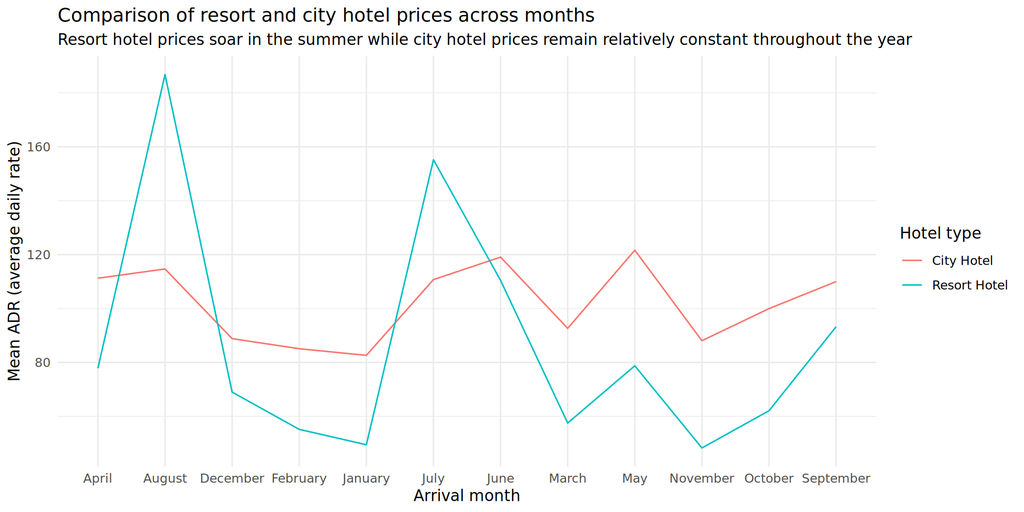

```r
hotels %>%
  group_by(hotel, arrival_date_month) %>%
  summarise(mean_adr = mean(adr)) %>%
  ggplot(aes(
    x = arrival_date_month,
    y = mean_adr,
    group = hotel,
    color = hotel)
    ) +
  geom_line() +
  theme_minimal() +
  labs(
    x = "Arrival month",
    y = "Mean ADR (average daily rate)",
    title = "Comparison of resort and city hotel prices across months",
    subtitle = "Resort hotel prices soar in the summer while city hotel prices remain relatively constant throughout the year",
    color = "Hotel type"
    )
```

**Task 2.1:** How are the months currently ordered on the x-axis? What order would make more sense?

**Your answer:**

The months are currently ordered alphabetically. It would make more sense to arrange them in calendar order from January through December.

**Task 2.2:** `arrival_date_month` is currently a character column, so R just sorts it alphabetically. Fix this by turning it into a factor with the levels in calendar order, then re-run the plot chunk above.

**Hint:** R has a built-in constant called `month.name` that’s already in calendar order — look it up by running `month.name` in your Console. You’ll want a function from the **forcats** package (see [forcats reference](https://forcats.tidyverse.org/reference/index.html)) to set the factor levels.

```r
# don't forget to switch eval = FALSE to TRUE after filling in the blanks
hotels <- hotels %>%
  mutate(
    arrival_date_month = factor(
      arrival_date_month,
      levels = month.name
    )
  )
```

**Task 2.3:** After re-knitting the plot with your fix, describe how the x-axis changed.

**Your answer:**

**Stretch goal (optional):** The y-axis currently shows plain numbers like `80`. Change the label so values display with dollar signs, e.g. `$80`. You’ll want a function from the **scales** package (see [scales reference](https://scales.r-lib.org/reference/index.html)).

```r
# Add scale_y_continuous(labels = ___) to the plot above
```

# Part 3: Importing and Recoding Data

## Exercise 3: Importing Data

When you read in a file, R has to guess the type of each column — and sometimes it guesses wrong, which can silently corrupt your data.

```r
orders_csv <- "id,city,zip_code,price
1,Boston,02139,\"$1,200\"
2,San Francisco,94105,\"$850\"
3,New York,10001,\"$1,500\"
4,Cambridge,02138,\"$950\""

orders <- read_csv(orders_csv)
```

Run `glimpse(orders)` in your Console and look closely at the `zip_code` and `price` columns.

**Task 3.1:** What type did `read_csv()` guess for `zip_code`? Compare the printed values to the original text above — did anything change? Why is that a problem for zip codes specifically?

**Your answer:**

**Task 3.2:** What type did `read_csv()` guess for `price`? Try running `mean(orders$price)` — what happens, and why?

**Your answer:**

read_csv() guessed that price was a character column. Running mean(orders$price) does not calculate the mean because R cannot perform numerical calculations on character values. The dollar signs and commas must first be removed and the values converted to numbers.

**Task 3.3:** Fix both problems. First, re-read the data telling `read_csv()` to keep `zip_code` as text using the `col_types` argument.

```r
# don't forget to switch eval = FALSE to TRUE after filling in the blanks
orders <- read_csv(
  orders_csv,
  col_types = cols(zip_code = col_character())
)
```

**Hint:** Look at the `col_types` examples in the R4DS Data Import reading — you want the “character” column type specifier.

Then, create a new column called `price_numeric` that strips the `$` and `,` out of `price` and converts it to a real number. Look up `parse_number()` from the **readr** package.

```r
# don't forget to switch eval = FALSE to TRUE after filling in the blanks
orders <- orders %>%
  mutate(price_numeric = parse_number(price))
```

**Task 3.4:** Verify your fix by running `mean(orders$price_numeric)`. What do you get?

**Your answer:** The mean price is $1,125.

## Exercise 4: Recoding Data — Dates and Times

Go back to the `hotels` data from Part 2. Right now, the booking date is split across three separate columns: `arrival_date_year`, `arrival_date_month` (a month name, like `"July"`), and `arrival_date_day_of_month`.

That’s fine for grouping by month like you did in Exercise 2, but it’s not useful if you wanted to know how many days apart two bookings were, or filter for a specific date range. For that, you need an actual `Date`.

**Task 4.1:** Use a function from **lubridate** to combine the three columns into one new column called `arrival_date`, containing a real `Date` value.

**Hint:** `lubridate::dmy()` can parse a string like `"1 July 2016"` directly into a date. You’ll need to `paste()` the three columns together first, in day-month-year order.

```r
# don't forget to switch eval = FALSE to TRUE after filling in the blanks
hotels <- hotels %>%
  mutate(
    arrival_date = dmy(
      paste(
        arrival_date_day_of_month,
        arrival_date_month,
        arrival_date_year
      )
    )
  )
```

**Task 4.2:** Verify your fix by running `class(hotels$arrival_date)`. What does it say now?

**Your answer:** The arrival_date column is now a Date class.

**Task 4.3 (reflect):** Now that `arrival_date` is a real date instead of just a releveled factor, what could you do with the data that you couldn’t easily do with the factor from Part 2?

**Your answer:**

Now I can sort and filter bookings by exact dates, calculate the number of days between bookings, and extract information such as the weekday, month, or year. These tasks would be more difficult with only a factor containing month names.

# Reflection

**What was the trickiest part of this exercise: type coercion, factors, importing, or dates?**

The trickiest part was importing data because R may guess the wrong data type. I had to inspect the columns, preserve ZIP codes as text, and convert prices into numeric values before performing calculations.

**How do you think the recoding/dates skills from Part 3 might come up in Lab 04?**

## These skills can help clean and prepare the data in Lab 04 before analyzing it. I may need to preserve identifiers as text, convert values into the correct type, and create real date columns so I can filter, organize, and calculate with the data.

# Submitting Your Work

**Before you finish:**

1. ✅ Make sure all code chunks run without errors
2. ✅ Fill in all blanks and answer all questions
3. ✅ Knit to HTML first to verify everything works
4. ✅ Review the HTML output

## Git Workflow

1. Click the **Git** pane
2. Check boxes next to all changed files
3. Click **Commit**
4. Write a commit message: “Completed AE 05 - Data Types, Factors & Dates”
5. Click **Commit**
6. Click **Push**
7. Verify your work is on GitHub in **YOUR fork**

## Generate PDF for Canvas Submission

Once everything works in HTML:

1. Click the **Knit** dropdown arrow
2. Select **Knit to PDF**
3. Wait for PDF generation
4. Find `ae-05-data-types.pdf` in the Files pane
5. Export and save to your computer
6. Submit the PDF to Canvas

**Remember:** Push your `.Rmd` to GitHub (your checkpoint/backup) AND submit the PDF to Canvas. **The PDF is the basis for grading** — make sure it’s complete and readable before you submit.

# Variables You’ll Need (Hotels Data)

| variable | class | description |
| --- | --- | --- |
| hotel | character | Hotel (Resort Hotel or City Hotel) |
| adr | double | Average Daily Rate |
| arrival_date_year | double | Year of arrival date |
| arrival_date_month | character | Month of arrival date (as text, e.g. “July”) |
| arrival_date_day_of_month | double | Day of arrival date |

For the full data dictionary, see AE 04’s instructions — this is the same `hotels` dataset.

# Troubleshooting

**Common issues:**

- **Error: “could not find function”:** Make sure you loaded the packages (`tidyverse` and `lubridate`)
- **`typeof()` line does nothing:** Make sure you actually removed the `#` in front of it
- **Factor levels don’t change the plot order:** Double-check you reassigned the result back with `hotels <- hotels %>% mutate(...)` — if you don’t save it back, R throws away your fix
- **`col_types` error:** Make sure you’re using `col_types = cols(column_name = "c")` or `col_character()`, not just `"character"` on its own
- **`parse_number()` returns `NA`:** Check that the column still has the `$`/`,` characters — `parse_number()` strips currency symbols and thousands separators automatically, but only from character columns, not already-numeric ones
- **`dmy()` returns `NA`:** Check the order of your `paste()` arguments — it needs to be day, then month, then year, matching the function name

**If you’re stuck:**

- Review the walkthrough video
- Check documentation: `?typeof`, `?factor`, `?col_types`, `?parse_number`, `?dmy`
- Ask on the discussion board
- Attend office hours

# Quick Reference

| Function | Package | Use |
| --- | --- | --- |
| `typeof()` | base R | Check the underlying type of a value or vector |
| `factor(x, levels = ...)` | base R | Turn a character vector into a factor with a specific level order |
| `col_types = cols(...)` | readr | Tell `read_csv()` exactly how to parse each column |
| `parse_number()` | readr | Pull a number out of text that has currency symbols, commas, etc. |
| `dmy()` / `mdy()` / `ymd()` | lubridate | Parse a text string into a real `Date`, based on the order of day/month/year |